# User_analysis

qingye

# 本报告对2017-10-20用户至2017-11-02这两周的行为进行了分析

#### 包括反映用户数目的UV,反映用户活跃度的：人均PV,用户活跃时长,以及反映用户黏度的次日留存，本次报告加入了路径深度的分析，并采用多种方式作图

#### 本次报告用R语言自动化生成报告的框架搭建，今后将在此基础上不断改进优化，下次报告将加入转化方面的分析，加深对于路径方面的分析，引进异常值提醒和分析，考虑加入排名变动

## 近两周的日活跃度(UV)

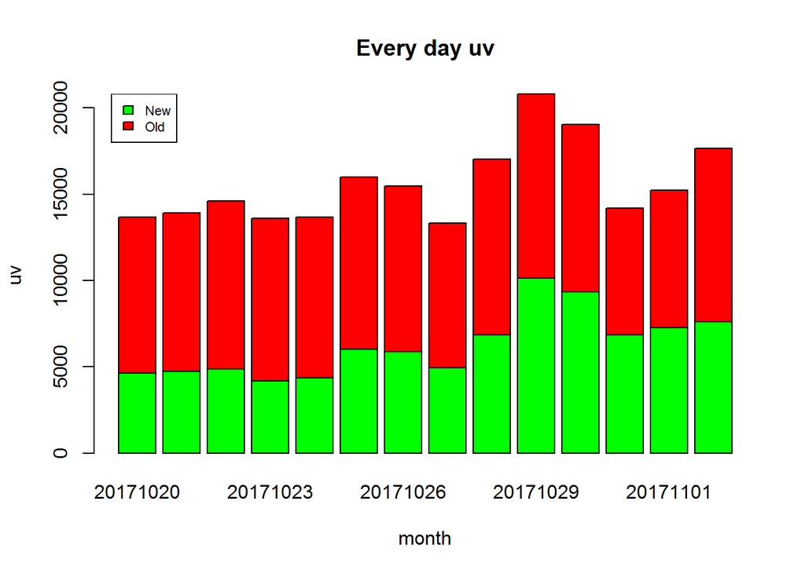

平均UV为15582,

最大UV为20805,

最大值发生在20171029

有0 天新用户在UV值上超过老用户

20171029 用户UV明显高于平均值 并没有哪天 用户UV明显低于平均值

## 近两周人均PV

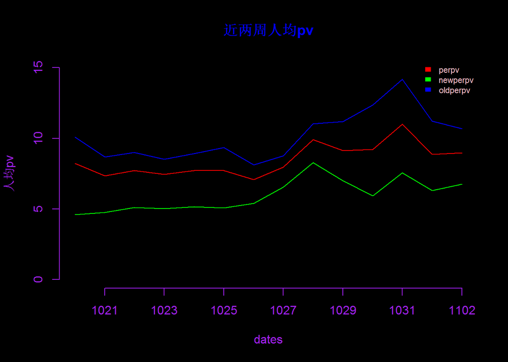

总体PV均值为8.4563373

总体PV最大值为10.9934525 最大值发生在 20171031

总体PV最小值为7.0886977 最小值发生在 20171026

新用户PV均值为5.9653581

新用户PV最大值为8.2735118 最大值发生在 20171028

新用户PV最小值为4.6044857 最小值发生在 20171020

老用户PV均值为10.1531973

老用户PV最大值为14.1739544 最大值发生在 20171031

老用户PV最小值为8.1236542 最小值发生在 20171026

有0 天新用户在人均PV值上超过老用户

20171021, 20171025, 20171026, 20171029, 20171030, 20171102 新用户和老用户的趋势不一样

## 用户活跃时长

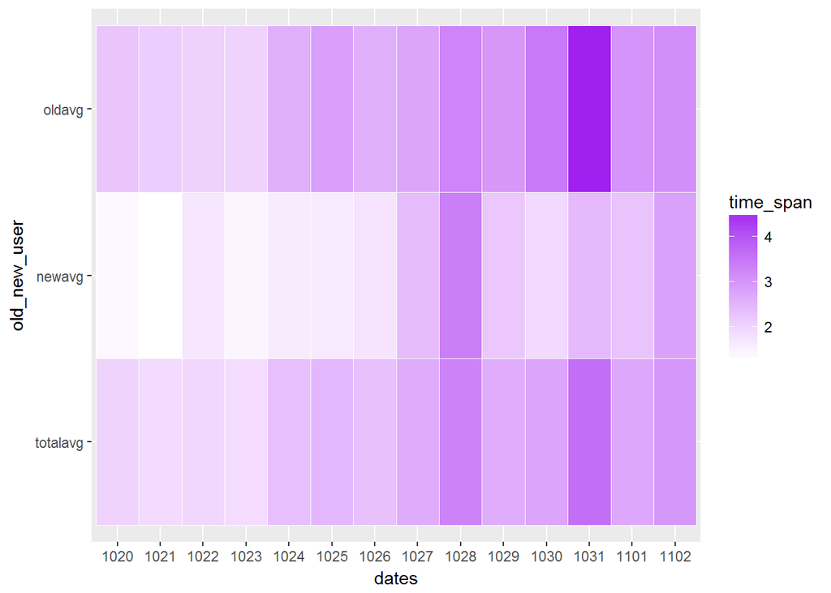

对于用户访问时长作的热力图，可以看出新老用户差距明显，新用户大部分日子访问时长接近白色，可能是今后的努力方向，不过值得留意的是，从10/27之后，新用户访问时间有了明显提升，可能有什么特别吸引他们的内容，值得研究

## 次日留存

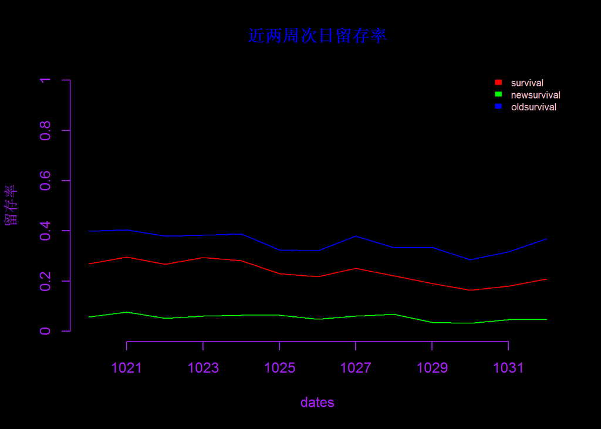

次日留存率，新用户并没有明显的波动，几乎保持水平，整体的波动几乎全部来源于老用户，老用户波动也很小

## 新老用户访问平均深度

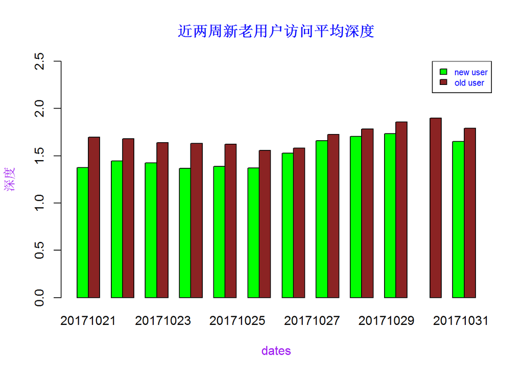

访问平均深度上，无论哪一天，新用户均少于老用户，且深度均低于2，大部分用户甚至还没有进入列表页

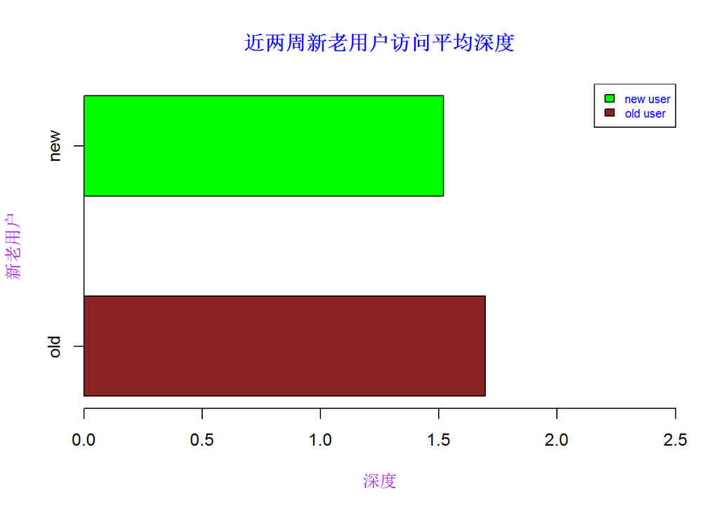

总体来看，新老用户访问深度差异明显

## 新用户不同机型分布

|  | model | 2017-10-20 | 2017-10-21 | 2017-10-22 | 2017-10-23 | 2017-10-24 | 2017-10-25 | 2017-10-26 | 2017-10-27 | 2017-10-28 | 2017-10-29 | 2017-10-30 | 2017-10-31 | 2017-11-01 | 2017-11-02 | sum |
| --- | --- | --- | --- | --- | --- | --- | --- | --- | --- | --- | --- | --- | --- | --- | --- | --- |
| 1 | iPhone | 288 | 304 | 372 | 305 | 290 | 380 | 477 | 453 | 575 | 653 | 653 | 397 | 496 | 591 | 6234 |
| 2 | iPhone 5c | 2 | 2 |  |  | 1 |  |  | 3 |  | 1619 | 1703 | 319 | 291 | 67 | 4007 |
| 3 | iPhone 6 | 65 | 58 | 88 | 59 | 83 | 116 | 133 | 148 | 207 | 539 | 576 | 350 | 294 | 188 | 2904 |
| 4 | Linux armv7l | 225 | 114 | 182 | 148 | 123 | 218 | 181 | 158 | 221 | 193 | 177 | 162 | 242 | 240 | 2584 |
| 5 | Linux armv8l | 97 | 118 | 91 | 133 | 132 | 200 | 146 | 144 | 245 | 338 | 206 | 130 | 203 | 353 | 2536 |
| 6 | iPhone 6 Plus | 42 | 67 | 86 | 48 | 62 | 79 | 127 | 94 | 155 | 519 | 500 | 305 | 270 | 175 | 2529 |
| 7 | iPhone 5 | 3 | 2 | 6 | 2 | 6 | 4 | 8 | 2 | 7 | 712 | 737 | 393 | 376 | 96 | 2354 |
| 8 | iPhone 5s | 11 | 11 | 13 | 10 | 17 | 26 | 18 | 27 | 45 | 696 | 697 | 351 | 326 | 101 | 2349 |
| 9 | vivo X9 | 144 | 124 | 121 | 124 | 130 | 157 | 103 | 85 | 279 | 219 | 242 | 240 | 179 | 198 | 2345 |
| 10 | iPhone 7 Plus | 51 | 80 | 102 | 67 | 69 | 83 | 99 | 108 | 156 | 166 | 194 | 155 | 196 | 152 | 1678 |

[output cut: 90 more lines]

本周加入了表格互动可以只看前20，表现比较好的手机还是iphone,vivo,以及一部分linux手机 值得注意的是iphone5c 在之前流量几乎为0，但是在10月29日有疯狂增长，有刷单嫌疑

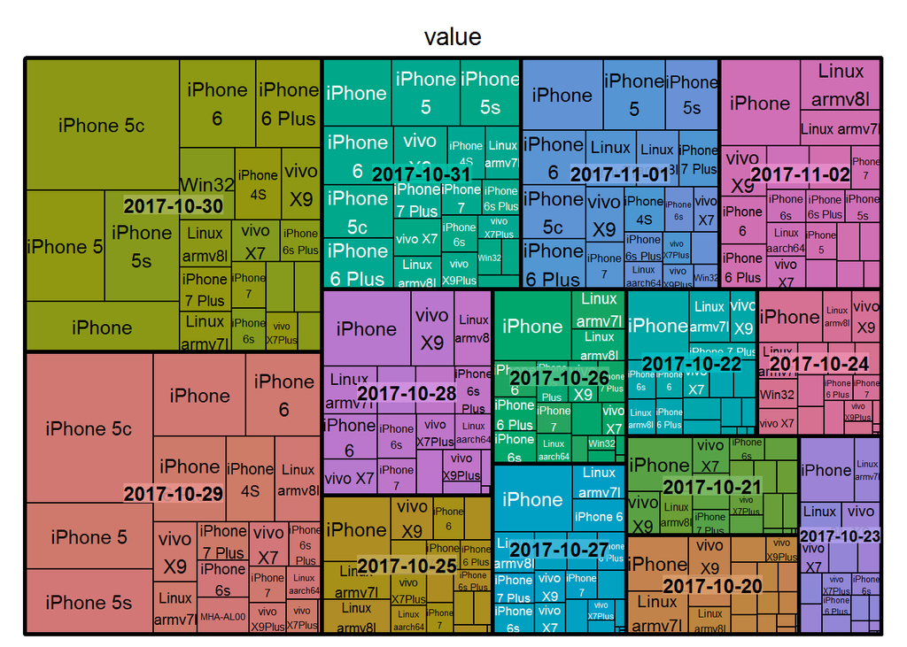

结构矩形树图，大矩形为日期，小矩形为具体机型，按从大到小的顺序，从上到下，从左到右排列

## 新用户不同城市分布

|  | city | 2017-10-20 | 2017-10-21 | 2017-10-22 | 2017-10-23 | 2017-10-24 | 2017-10-25 | 2017-10-26 | 2017-10-27 | 2017-10-28 | 2017-10-29 | 2017-10-30 | 2017-10-31 | 2017-11-01 | 2017-11-02 | sum |
| --- | --- | --- | --- | --- | --- | --- | --- | --- | --- | --- | --- | --- | --- | --- | --- | --- |
| 1 | 上海 | 842 | 886 | 1111 | 876 | 952 | 1341 | 1370 | 1321 | 1922 | 2591 | 2068 | 1206 | 1539 | 2364 | 18850 |
| 2 | 苏州 | 110 | 179 | 206 | 119 | 237 | 391 | 468 | 496 | 942 | 984 | 1302 | 1062 | 1044 | 1218 | 7714 |
| 3 | 北京 | 334 | 414 | 427 | 426 | 326 | 413 | 464 | 411 | 639 | 666 | 567 | 475 | 390 | 558 | 6120 |
| 4 | 南京 | 227 | 207 | 315 | 163 | 206 | 300 | 346 | 420 | 726 | 902 | 399 | 380 | 317 | 403 | 4994 |
| 5 | 沈阳 | 81 | 81 | 69 | 58 | 69 | 112 | 68 | 76 | 90 | 1319 | 1307 | 64 | 83 | 73 | 3467 |
| 6 | 清远 | 3 | 9 | 10 | 3 | 4 | 6 | 4 | 8 | 4 | 1005 | 1002 | 2 | 3 | 5 | 2065 |
| 7 | 合肥 | 89 | 133 | 123 | 92 | 101 | 177 | 121 | 125 | 153 | 178 | 169 | 105 | 115 | 200 | 1766 |
| 8 | 济南 | 82 | 82 | 72 | 70 | 70 | 108 | 123 | 66 | 102 | 125 | 124 | 137 | 138 | 107 | 1268 |
| 9 | 成都 | 100 | 69 | 101 | 71 | 97 | 118 | 98 | 75 | 97 | 165 | 125 | 75 | 95 | 99 | 1290 |
| 10 | 重庆 | 86 | 91 | 80 | 85 | 79 | 88 | 109 | 82 | 156 | 107 | 126 | 81 | 60 | 75 | 1245 |

[output cut: 91 more lines]

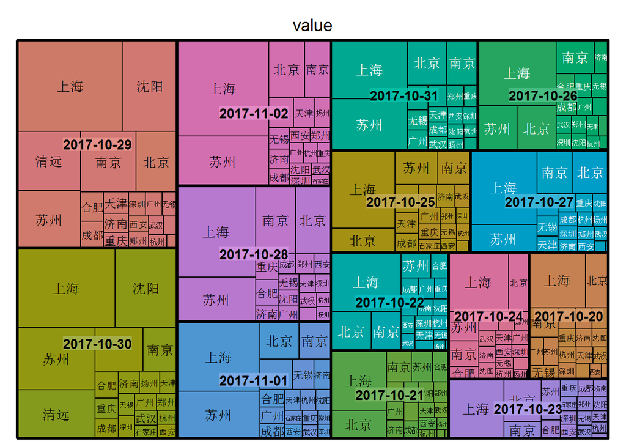

结构矩形树图，大矩形为日期，小矩形为具体城市，按从大到小的顺序，从上到下，从左到右排列

## 新用户不同渠道分布

|  | channels | 2017-10-20 | 2017-10-21 | 2017-10-22 | 2017-10-23 | 2017-10-24 | 2017-10-25 | 2017-10-26 | 2017-10-27 | 2017-10-28 | 2017-10-29 | 2017-10-30 | 2017-10-31 | 2017-11-01 | 2017-11-02 | sum |
| --- | --- | --- | --- | --- | --- | --- | --- | --- | --- | --- | --- | --- | --- | --- | --- | --- |
| 1 | 30015 | 1144 | 1131 | 1324 | 1066 | 1068 | 1525 | 1549 | 1568 | 1990 | 2137 | 1995 | 1227 | 1684 | 2588 | 21996 |
| 2 | 360手助 | 1647 | 1587 | 1447 | 1397 | 1388 | 1895 | 1814 | 1058 | 609 | 805 | 869 | 366 | 835 | 771 | 16488 |
| 3 | 二维码-IOS | 36 | 68 | 106 | 33 | 82 | 153 | 162 | 181 | 396 | 1283 | 620 | 2002 | 1942 | 765 | 7829 |
| 4 | Appstore | 176 | 238 | 305 | 252 | 248 | 286 | 289 | 304 | 345 | 1853 | 2376 | 314 | 265 | 292 | 7543 |
| 5 | 二维码-Android | 77 | 78 | 106 | 64 | 105 | 391 | 462 | 537 | 943 | 1149 | 922 | 660 | 740 | 1191 | 7425 |
| 6 | vivo | 1 |  |  |  | 1 | 2 | 2 | 197 | 1002 | 901 | 960 | 965 | 629 | 658 | 5318 |
| 7 | VIVO应用商店 | 618 | 663 | 545 | 518 | 527 | 585 | 271 | 78 | 18 | 4 | 7 | 4 | 2 | 4 | 3844 |
| 8 | 华为 |  |  |  | 1 |  | 1 |  | 72 | 242 | 454 | 345 | 206 | 221 | 227 | 1769 |
| 9 | 百度手助 | 101 | 78 | 99 | 80 | 59 | 191 | 72 | 120 | 161 | 177 | 136 | 163 | 108 | 71 | 1616 |
| 10 | 联通沃商店1 | 175 | 217 | 241 | 197 | 217 | 232 | 213 | 57 | 6 | 2 | 1 | 1 | 1 | 2 | 1562 |

[output cut: 34 more lines]

二维码，30015，appstore,360助手都占据不错份额，360助手平时占比更高

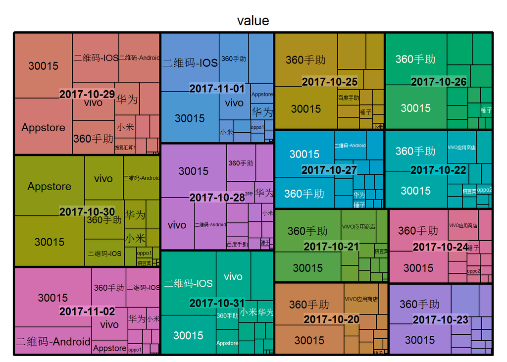

结构矩形树图，大矩形为日期，小矩形为具体渠道，按从大到小的顺序，从上到下，从左到右排列

# 转化问题

## 每日订单数

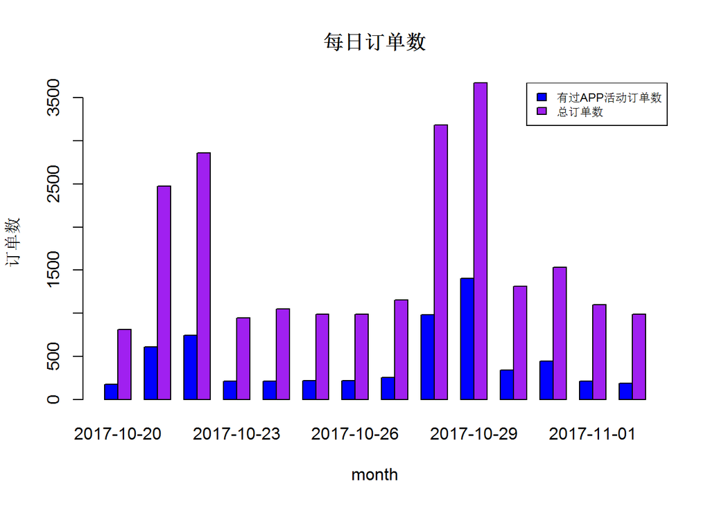

在APP上有过活动的人生成的订单大概占总订单的五分之一到三分之一，21，22，28，29四天订单数较多

## 房产预约

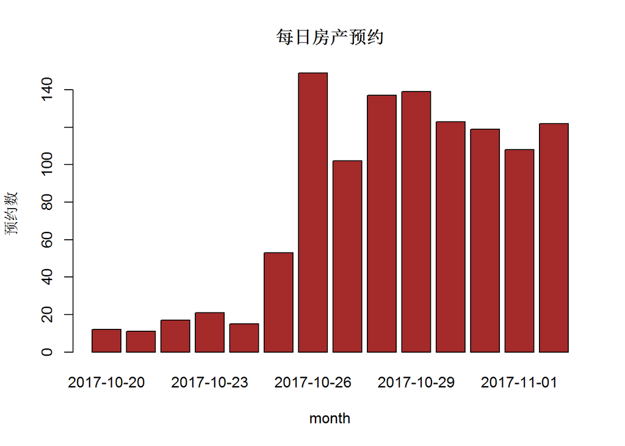

房产预约在10月26日以后有个大幅的增长，且之后维持在比较高的水准

## 领券情况

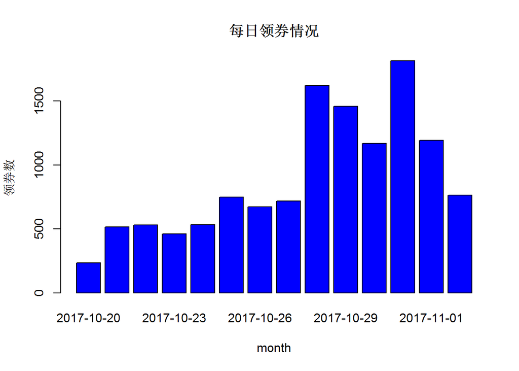

领券在10月28日以后有大幅的增长，且维持在比较高的水准